R-Ladies: Introduction to Data Cleaning with `dataMaid` Molly Olson, MS March 19, 2018

# What is the `dataMaid` package?

Show

# Goals

Show

# Examples of errors in data and data cleaning checks

Show

# Workflow with `dataMaid`

Show

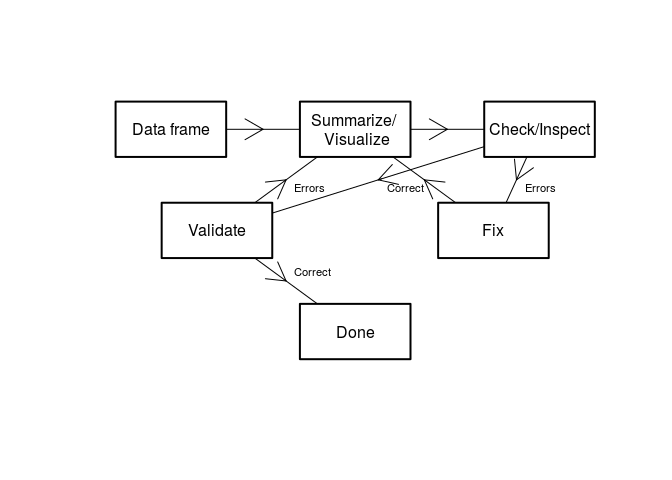

Summarize: What information does the variable have?  
Visualize: What does the distribution of the variable look like?  
Check: What potential problems are there with the variable?  
Fix: Fix problems.  
Validate: Did we actually fix the problem and/or check row-wise errors.

# Summarize/Visualize

Show

| makeDataReport {dataMaid} | R Documentation |
| --- | --- |

## Produce a data report

### Description

Make a data overview report that summarizes the contents of a dataset and flags potential problems. The potential problems are identified by running a set of class-specific validation checks, so that different checks are performed on different variables types. The checking steps can be customized according to user input and/or data type of the inputted variable. The checks are saved to an R markdown file which can rendered into an easy-to-read data report in pdf, html or word formats. This report also includes summaries and visualizations of each variable in the dataset.

### Usage

```
makeDataReport(data, output = NULL, render = TRUE, useVar = NULL,
  ordering = c("asIs", "alphabetical"), onlyProblematic = FALSE,
  labelled_as = c("factor"), mode = c("summarize", "visualize", "check"),
  smartNum = TRUE, preChecks = c("isKey", "isSingular", "isSupported"),
  file = NULL, replace = FALSE, vol = "", standAlone = TRUE,
  twoCol = TRUE, quiet = TRUE, openResult = TRUE,
  summaries = setSummaries(), visuals = setVisuals(),
  checks = setChecks(), listChecks = TRUE, maxProbVals = 10,
  maxDecimals = 2, addSummaryTable = TRUE, codebook = FALSE,
  reportTitle = NULL, treatXasY = NULL, ...)
```

### Arguments

| `data` | The dataset to be checked. This dataset should be of class `data.frame`, `tibble` or `matrix`. If it is of classs `matrix`, it will be converted to a `data.frame`. |
| --- | --- |
| `output` | Output format. Options are `“pdf”`, `“word”` (.docx) and `“html”`. If `NULL` (the default), the output format depends two sequential checks. First, whether a LaTeX installation is available, in which … |
| `render` | Should the output file be rendered (defaults to `TRUE`), i.e. should a pdf/word/html document be generated and saved to the disc? |
| `useVar` | Variables to describe in the report. If `NULL` (the default), all variables in `data` are included. If a vector of variable names is supplied, only the variables in `data` that are also in `useVar` ar… |
| `ordering` | Choose the ordering of the variables in the variable presentation. The options are “asIs” (ordering as in the dataset) and “alphabetical” (alphabetical order). |
| `onlyProblematic` | A logical. If `TRUE`, only the variables flagged as problematic in the check step will be included in the variable list. |
| `labelled_as` | A string explaining the way to handle labelled vectors. Currently `“factor”` (the default) is the only possibility. This means that labelled variables that appear factor-like (by having a non-`NULL` `… |
| `mode` | Vector of tasks to perform among the three categories “summarize”, “visualize” and “check”. The default, `c(“summarize”, “visualize”, “check”)`, implies that all three steps are performed. The steps s… |
| `smartNum` | If `TRUE` (the default), numeric and integer variables with less than 5 unique values are treated as factor variables in the checking, visualization and summary steps, and a message notifying the read… |
| `preChecks` | Vector of function names for check functions used in the pre-check stage. The pre-check stage consists of variable checks that should be performed before the summary/visualization/checking step. If an… |
| `file` | The filename of the outputted rmarkdown (.Rmd) file. If set to `NULL` (the default), the filename will be the name of `data` prefixed with “dataMaid_”, if this qualifies as a valid file name (e.g. no … |
| `replace` | If `FALSE` (the default), an error is thrown if one of the files that we are about to be created (.Rmd overview file and possible also a .html, .pdf or .docx file) already exist. If `TRUE`, no checks … |
| `vol` | Extra text string or numeric that is appended on the end of the output file name(s). For example, if the dataset is called “myData”, no file argument is supplied and `vol=2`, the output file will be c… |
| `standAlone` | A logical. If `TRUE`, the document begins with a markdown YAML preamble such that it can be rendered as a stand alone rmarkdown file, e.g. by calling `render`. If `FALSE`, this preamble is removed. Mo… |
| `twoCol` | A logical. Should the results from the *summarize* and *visualize* steps be presented in two columns? Defaults to `TRUE`. |
| `quiet` | A logical. If `TRUE` (the default), only a few messages are printed to the screen as `makeDataReport` runs. If `FALSE`, no messages are suppressed. The third option, `silent`, renders the function com… |
| `openResult` | A logical. If `TRUE` (the default), the last file produced by `makeDataReport` is automatically opened by the end of the function run. This means that if `render = TRUE`, the rendered pdf, word or htm… |
| `summaries` | A list of summaries to use on each supported variable type. We recommend using `setSummaries` for creating this list and refer to the documentation of this function for more details. |
| `visuals` | A list of visual functions to use on each supported variable type. We recommend using `setVisuals` for creating this list and refer to the documentation of this function for more details. |
| `checks` | A list of checks to use on each supported variable type. We recommend using `setChecks` for creating this list and refer to the documentation of this function for more details. |
| `listChecks` | A logical. Controls whether what checks that were used for each possible variable type are summarized in the output. Defaults to `TRUE`. |
| `maxProbVals` | A positive integer or `Inf`. Maximum number of unique values printed from check-functions. In the case of `Inf`, all problematic values are printed. Defaults to `10`. |
| `maxDecimals` | A positive integer or `Inf`. Number of decimals used when printing numerical values in the data summary and in problematic values from the data checks. If `Inf`, no rounding is performed. |
| `addSummaryTable` | A logical. If `TRUE` (the default), a summary table of the variable checks is added between the Data Cleaning Summary and the Variable List. Only one of `addSummaryTable` and `addCodebookTable` can be… |
| `codebook` | A logical. Defaults to `FALSE`. If `TRUE` then the document is tweaked to better represent a codebook. |
| `reportTitle` | A text string. If supplied, this will be the printed title of the report. If left unspecified, the title with the name of the supplied dataset. |
| `treatXasY` | A list that indicates how non-standard variable classes should be treated. This parameter allows you to include variables that are not of class `factor`, `character`, `labelled`, `numeric`, `integer`,… |
| `…` | Other arguments that are passed on the to precheck, checking, summary and visualization functions. |

### Details

For each variable, a set of pre-check functions (controlled by the `preChecks` argument) are first run and then then a battery of functions are applied depending on the variable class. For each variable type the summarize/visualize/check functions are applied and and the results are written to an R markdown file.

### Value

The function does not return anything. Its side effect (the production of a data report) is the reason for running the function.

### Examples

```
data(testData)
data(toyData)

check(toyData)

 ## Not run:
DF <- data.frame(x = 1:15)
makeDataReport(DF)

## End(Not run)

## Not run:
data(testData)
makeDataReport(testData)

## End(Not run)

# Overwrite any existing files generated by makeDataReport
## Not run:
makeDataReport(testData, replace=TRUE)

## End(Not run)

# Change output format to Word/docx:
## Not run:
makeDataReport(testData, replace=TRUE, output = "word")

## End(Not run)

# Only include problematic variables in the output document
## Not run:
makeDataReport(testData, replace=TRUE, onlyProblematic=TRUE)

## End(Not run)

# Add user defined check-function to the checks performed on character variables:
# Here we add functionality to search for the string wally (ignoring case)
## Not run:
wheresWally <- function(v, ...) {
     res <- grepl("wally", v, ignore.case=TRUE)
```

[output cut: 14 more lines]

```
      replace=TRUE)

## End(Not run)

#Handle non-supported variable classes using treatXasY: treat raw as character and
#treat complex as numeric. We also add a list variable, but as lists are not
#handled through treatXasY, this variable will be caught in the preChecks and skipped:
## Not run:
toyData$rawVar <- as.raw(c(1:14, 1))
toyData$compVar <- c(1:14, 1) + 2i
toyData$listVar <- as.list(c(1:14, 1))
makeDataReport(toyData, replace  = TRUE,
    treatXasY = list(raw = "character", complex = "numeric"))

## End(Not run)
```

[Package *dataMaid* version 1.1.0 Index]

Show

```r
require(dataMaid)
head(bigPresidentData)
```

```
##      lastName firstName orderOfPresidency   birthday dateOfDeath  stateOfBirth       party presidencyBeginDate presidencyEndDate assassinationAttempt
## 38       Ford    Gerald                38 1913-07-14  2006-12-26      Nebraska  Republican          1974-08-09        1977-01-20                    1
## 2       Adams      John                 2 1735-10-30  1826-07-04 Massachusetts  Federalist          1797-03-04        1801-03-04                    0
## 31     Hoover   Herbert                31 1874-08-10  1964-10-20          Iowa  Republican          1929-03-04        1933-03-04                    0
## 1  Washington    George                 1 1732-02-22  1799-12-14      Virginia Independent          1789-04-30        1797-03-04                    0
## 13   Fillmore   Millard                13 1800-01-07  1874-03-08      New York        Whig          1850-07-09        1853-03-04                    0
## 42    Clinton   William                42 1946-08-19        <NA>      Arkansas  Democratic          1993-01-20        2001-01-20                    0
##     sex ethnicity presidencyYears ageAtInauguration favoriteNumber
## 38 Male Caucasian               2                61           2+0i
## 2  Male Caucasian               3                61           4+0i
## 31 Male Caucasian               4                54           5+0i
## 1  Male Caucasian               7                57           3+0i
## 13 Male Caucasian               2                50           7+0i
## 42 Male Caucasian               8                46           7+0i
```

```r
bigPresidentData <- as.data.table(bigPresidentData)
```

```r
makeDataReport(bigPresidentData)
```

**Default report:**

- Identifies miscoded missing values
- Identifies prefixed and suffixed (the following appear with the prefix or suffix *x*)
- Checks whitespaces
- Identifies levels with < 6 observations
- Identifies case issues
- Identifies misclassified numeric or integer variables
- Identifies outliers
- Provides a summary table of variable class, number of unique observations, missingness and any problems
- “Column-wise” checks

## Using `dataMaid` interactively

Check

```r
allCheckFunctions()
```

Table continues below

| name | description |
| --- | --- |
| identifyCaseIssues | Identify case issues |
| identifyLoners | Identify levels with < 6 obs. |
| identifyMissing | Identify miscoded missing values |
| identifyNums | Identify misclassified numeric or integer variables |
| identifyOutliers | Identify outliers |
| identifyOutliersTBStyle | Identify outliers (Turkish Boxplot style) |
| identifyWhitespace | Identify prefixed and suffixed whitespace |
| isCPR | Identify Danish CPR numbers |
| isEmpty | Check if the variable contains only a single value |
| isKey | Check if the variable is a key |
| isSingular | Check if the variable contains only a single value |
| isSupported | Check if the variable class is supported by dataMaid. |

| classes |
| --- |
| character, factor |
| character, factor |
| character, Date, factor, integer, labelled, logical, numeric |
| character, factor, labelled |
| Date, integer, numeric |
| Date, integer, numeric |
| character, factor, labelled |
| character, Date, factor, integer, labelled, logical, numeric |
| character, Date, factor, integer, labelled, logical, numeric |
| character, Date, factor, integer, labelled, logical, numeric |
| character, Date, factor, integer, labelled, logical, numeric |
| character, Date, factor, integer, labelled, logical, numeric |

```r
## syntax

## numeric class
check(bigPresidentData$presidencyYears
      , numericChecks = c("identifyMissing","identifyOutliers"))
```

```
## $identifyMissing
## The following suspected missing value codes enter as regular values: Inf.
## $identifyOutliers
## Note that the following possible outlier values were detected: 12, Inf.
```

```r
check(bigPresidentData$presidencyYears
      , checks = setChecks(numeric = c("identifyMissing")))
```

```
## $identifyMissing
## The following suspected missing value codes enter as regular values: Inf.
```

```r
check(bigPresidentData$presidencyYears
      , checks = setChecks())
```

```
## $identifyMissing
## The following suspected missing value codes enter as regular values: Inf.
## $identifyOutliers
## Note that the following possible outlier values were detected: 12, Inf.
```

```r
## factor class
check(bigPresidentData$ethnicity
      , factorChecks = c("identifyCaseIssues","identifyLoners"))
```

```
## $identifyCaseIssues
## No problems found.
## $identifyLoners
## Note that the following levels have at most five observations: African American.
```

```r
check(bigPresidentData$ethnicity
      , checks = setChecks(factor = c("identifyLoners")))
```

```
## $identifyLoners
## Note that the following levels have at most five observations: African American.
```

```r
check(bigPresidentData$ethnicity
      , checks = setChecks())
```

```
## $identifyMissing
## No problems found.
## $identifyWhitespace
## No problems found.
## $identifyLoners
## Note that the following levels have at most five observations: African American.
## $identifyCaseIssues
## No problems found.
## $identifyNums
## No problems found.
```

```r
## both
check(bigPresidentData[,.(ethnicity, presidencyYears)]
      , checks = setChecks(numeric = "identifyOutliers"
                         , factor  = "identifyLoners"))
```

```
## $ethnicity
## $ethnicity$identifyLoners
## Note that the following levels have at most five observations: African American.
##
## $presidencyYears
## $presidencyYears$identifyOutliers
## Note that the following possible outlier values were detected: 12, Inf.
```

```r
identifyWhitespace(bigPresidentData$firstName)
```

```
## No problems found.
```

```r
identifyWhitespace(bigPresidentData$lastName)
```

```
## The following values appear with prefixed or suffixed white space:  Truman.
```

```r
check(bigPresidentData[,.(firstName, lastName)]
      , checks = setChecks(character = "identifyWhitespace"))
```

```
## $firstName
## $firstName$identifyWhitespace
## No problems found.
##
## $lastName
## $lastName$identifyWhitespace
## The following values appear with prefixed or suffixed white space:  Truman.
```

Visualize

```r
allVisualFunctions()
```

| name | description | classes |
| --- | --- | --- |
| basicVisual | Histograms and barplots using graphics | character, Date, factor, integer, labelled, logical, numeric |
| standardVisual | Histograms and barplots using ggplot2 | character, Date, factor, integer, labelled, logical, numeric |

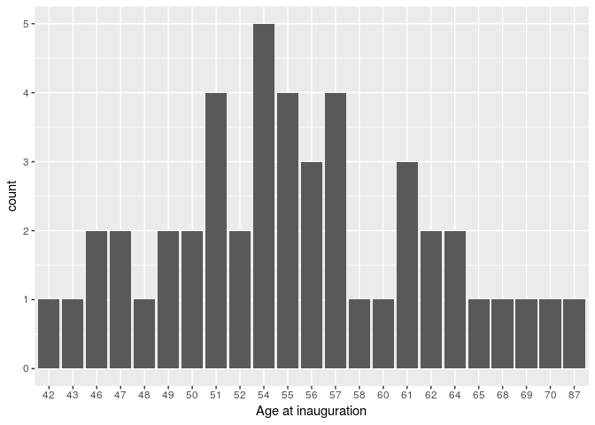

```r
visualize(bigPresidentData$ageAtInauguration, vnam = "Age at inauguration")
```

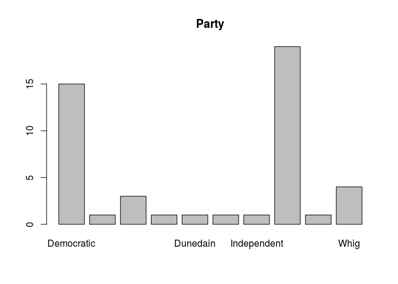

```r
basicVisual(bigPresidentData$party, vnam = "Party")
```

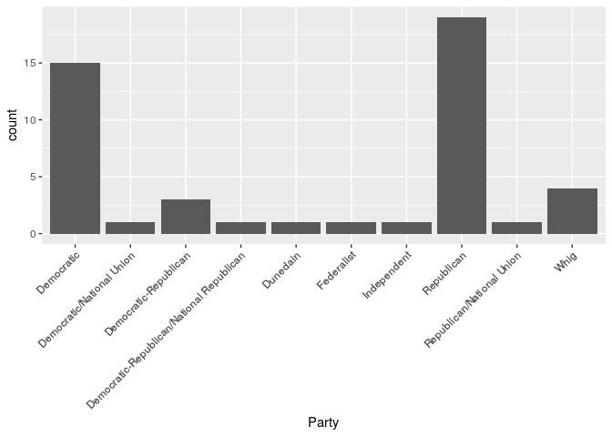

```r
standardVisual(bigPresidentData$party, vnam = "Party") + theme(axis.text.x = element_text(angle = 45, hjust = 1))
```

Summarize

```r
allSummaryFunctions()
```

| name | description | classes |
| --- | --- | --- |
| centralValue | Compute median for numeric variables, mode for categorical variables | character, Date, factor, integer, labelled, logical, numeric |
| countMissing | Compute proportion of missing observations | character, Date, factor, integer, labelled, logical, numeric |
| minMax | Find minimum and maximum values | integer, numeric, Date |
| quartiles | Compute 1st and 3rd quartiles | Date, integer, numeric |
| uniqueValues | Count number of unique values | character, Date, factor, integer, labelled, logical, numeric |
| variableType | Data class of variable | character, Date, factor, integer, labelled, logical, numeric |

```r
summarize(bigPresidentData$lastName)
```

```
## $variableType
## Variable type: character
## $countMissing
## Number of missing obs.: 0 (0 %)
## $uniqueValues
## Number of unique values: 40
## $centralValue
## Mode: "Adams"
```

```r
# summarize(bigPresidentData)

lapply(bigPresidentData, variableType) %>% head
```

```
## $lastName
## Variable type: character
## $firstName
## Variable type: character
## $orderOfPresidency
## Variable type: factor
## $birthday
## Variable type: Date
## $dateOfDeath
## Variable type: Date
## $stateOfBirth
## Variable type: character
```

## Extending `dataMaid`

Show

Customize your own checking, visual, or summary functions!

**Templates:**

```r
mySummaryFunction <- summary(v, ...){
  val <- [ result of whatever summary you want to do ]
  res <- [ properly escaped version of val ]
  summaryResult(list( feature = "[Feature name]"
                    , result  = res
                    , value   = val
                ))
}
```

```r
isSNN <- function(v, nMax = NULL, ...){
  out <- list(problem = FALSE
            , message = ""
            , problemValues = NULL)
  if (class(v) %in% c("character","factor","labelled")){
    if(any(grep("\\d{3}-\\d{3}-\\d{4}",v))) {
      out$problem <- TRUE
      out$message <- "Warning: may contain SSNs"
      out$problemValues <- "Will not show"
    }
  }
  out
}
```

**Examples:**

*Basic example:*

```r
refCat <- function(v, ...) {
  out <- list(factor = FALSE
            , reference = ""
            , problemValues = NULL)
  if(class(v) %in% c("factor")) {
    out$factor <- TRUE
    out$reference <- levels(v)[1]
    out$problemValues <- "Not applicable"
  }
  out
}

refCat <- summaryFunction(refCat
                        , description = "Identifies reference level"
                        , classes = c("factor"))

check(bigPresidentData$sex, factorChecks = "refCat")
```

```
## $refCat
## $refCat$factor
## [1] TRUE
##
## $refCat$reference
## [1] "Male"
##
## $refCat$problemValues
## [1] "Not applicable"
```

*More advanced example:*

```r
identifyNonStartCase <- function(v, nMax = 10, ...){
  v <- unique(na.omit(v)) ## omit NA values and keep only unique values
  vSplit <- strsplit(v, split = " ") ## split around blank spaces
  vSplitAllLower <- sapply(vSplit, tolower) ## make all lowercase
  helper <- function(x){ ## helper function to make first letter capital
    capFirstLetters <- toupper(substring(x, 1, 1))
    x <- paste(capFirstLetters, substring(x, 2), sep = "")
    x
  }
  vSplitStartCase <- sapply(vSplit, helper) ## first letter capital version of v
  vStartCase <- sapply(vSplitStartCase, function(x) paste(x, collapse = " "))

  ## find where v and vStartCase differ
  problemPlaces <- v != vStartCase

  if(any(problemPlaces)){
    problemValues <- v[problemPlaces]
  } else {
    problemValues <- NULL
  }

  problem <- any(problemPlaces)

  problemStatus <- list(problem = problem
                      , problemValues = problemValues)
  problemMessage <- "The following variables were not in start case:"
  outMessage <- messageGenerator(problemStatus, problemMessage, nMax)

  checkResult(list(problem = problem
                 , message = outMessage
                 , problemValues = problemValues))
}

identifyNonStartCase <- checkFunction(identifyNonStartCase
                                    , description = "Identifies entries that are not written in start case"
                                    , classes = c("character", "factor"))

check(bigPresidentData$stateOfBirth, checks = setChecks(character = "identifyNonStartCase"))
```

```
## $identifyNonStartCase
## The following variables were not in start case: New york.
```

```r
allCheckFunctions()
```

Table continues below

| name | description |
| --- | --- |
| identifyNonStartCase | Identifies entries that are not written in start case |
| identifyCaseIssues | Identify case issues |
| identifyLoners | Identify levels with < 6 obs. |
| identifyMissing | Identify miscoded missing values |
| identifyNums | Identify misclassified numeric or integer variables |
| identifyOutliers | Identify outliers |
| identifyOutliersTBStyle | Identify outliers (Turkish Boxplot style) |
| identifyWhitespace | Identify prefixed and suffixed whitespace |
| isCPR | Identify Danish CPR numbers |
| isEmpty | Check if the variable contains only a single value |
| isKey | Check if the variable is a key |
| isSingular | Check if the variable contains only a single value |
| isSupported | Check if the variable class is supported by dataMaid. |

| classes |
| --- |
| character, factor |
| character, factor |
| character, factor |
| character, Date, factor, integer, labelled, logical, numeric |
| character, factor, labelled |
| Date, integer, numeric |
| Date, integer, numeric |
| character, factor, labelled |
| character, Date, factor, integer, labelled, logical, numeric |
| character, Date, factor, integer, labelled, logical, numeric |
| character, Date, factor, integer, labelled, logical, numeric |
| character, Date, factor, integer, labelled, logical, numeric |
| character, Date, factor, integer, labelled, logical, numeric |

# Validate

Show

```r
require(validate)
```

This mostly serves as a logic check (ex. death date is later than birth date) and row-wise checks.

First, create a `validator` object:

```r
validator1 <- validator(
  ageAtDeath := floor((dateOfDeath - birthday)/365.25)
  , `Adult president` = ageAtInauguration >= 18
  , `Alive at inauguration` = ageAtDeath >= ageAtInauguration
  , `Positive first name` = firstName*2 > firstName
  , `Death by assassination` =
             if (dateOfDeath == presidencyEndDate)
               assassinationAttempt == 1
  , `Begin date` = difftime(presidencyEndDate, as.Date("176-08-04")) > 0
)
```

```r
confront_messy <- confront(bigPresidentData, validator1)
summary(confront_messy) %>% kable
```

| name | items | passes | fails | nNA | error | warning | expression |
| --- | --- | --- | --- | --- | --- | --- | --- |
| Adult.president | 47 | 47 | 0 | 0 | FALSE | FALSE | ageAtInauguration >= 18 |
| Alive.at.inauguration | 47 | 40 | 1 | 6 | FALSE | FALSE | floor((dateOfDeath - birthday)/365.25) >= ageAtInauguration |
| Positive.first.name | 0 | 0 | 0 | 0 | TRUE | FALSE | firstName * 2 > firstName |
| Death.by.assassination | 47 | 38 | 3 | 6 | FALSE | FALSE | !(dateOfDeath == presidencyEndDate) \| (abs(assassinationAttempt - 1) < 1e-08) |
| Begin.date | 47 | 45 | 0 | 2 | FALSE | FALSE | difftime(presidencyEndDate, as.Date(“176-08-04”)) > 0 |

```r
errors(confront_messy)
```

```
## $Positive.first.name
## [1] "non-numeric argument to binary operator"
```

```r
bpd_clean <- readRDS("bigPresidentData_cleaned.rds")
confront_clean <- confront(bpd_clean, validator1)
summary(confront_clean) %>% kable
```

| name | items | passes | fails | nNA | error | warning | expression |
| --- | --- | --- | --- | --- | --- | --- | --- |
| Adult.president | 45 | 45 | 0 | 0 | FALSE | FALSE | (ageAtInauguration - 18) >= -1e-08 |
| Alive.at.inauguration | 45 | 39 | 0 | 6 | FALSE | FALSE | floor((dateOfDeath - birthday)/365.25) >= ageAtInauguration |
| Positive.first.name | 0 | 0 | 0 | 0 | TRUE | FALSE | firstName * 2 > firstName |
| Death.by.assassination | 45 | 36 | 3 | 6 | FALSE | FALSE | !(dateOfDeath == presidencyEndDate) \| (abs(assassinationAttempt - 1) < 1e-08) |
| Begin.date | 45 | 44 | 0 | 1 | FALSE | FALSE | difftime(presidencyEndDate, as.Date(“176-08-04”)) > 0 |

```r
orderVal <- validator(rank(presidencyBeginDate) == rank(orderOfPresidency))

orderCon_messy <- confront(
  na.omit(bigPresidentData[,.(presidencyBeginDate, orderOfPresidency)])
  , orderVal
)
summary(orderCon_messy) %>% kable
```

| name | items | passes | fails | nNA | error | warning | expression |
| --- | --- | --- | --- | --- | --- | --- | --- |
| V1 | 46 | 44 | 2 | 0 | FALSE | FALSE | rank(presidencyBeginDate) == rank(orderOfPresidency) |

```r
orderCon_clean <- confront(
  na.omit(bpd_clean[,.(presidencyBeginDate, orderOfPresidency)])
  , orderVal
)
summary(orderCon_clean) %>% kable
```

| name | items | passes | fails | nNA | error | warning | expression |
| --- | --- | --- | --- | --- | --- | --- | --- |
| V1 | 45 | 43 | 2 | 0 | FALSE | FALSE | rank(presidencyBeginDate) == rank(orderOfPresidency) |

Overview of confrontation results:

```r
summary(confront_messy)
```

```
##                     name items passes fails nNA error warning                                                                    expression
## 1        Adult.president    47     47     0   0 FALSE   FALSE                                                       ageAtInauguration >= 18
## 2  Alive.at.inauguration    47     40     1   6 FALSE   FALSE                   floor((dateOfDeath - birthday)/365.25) >= ageAtInauguration
## 3    Positive.first.name     0      0     0   0  TRUE   FALSE                                                     firstName * 2 > firstName
## 4 Death.by.assassination    47     38     3   6 FALSE   FALSE !(dateOfDeath == presidencyEndDate) | (abs(assassinationAttempt - 1) < 1e-08)
## 5             Begin.date    47     45     0   2 FALSE   FALSE                         difftime(presidencyEndDate, as.Date("176-08-04")) > 0
```

Compute percentage pass/fail/NA:

```r
aggregate(confront_messy)
```

```
##                        npass nfail nNA  rel.pass   rel.fail     rel.NA
## Adult.president           47     0   0 1.0000000 0.00000000 0.00000000
## Alive.at.inauguration     40     1   6 0.8510638 0.02127660 0.12765957
## Death.by.assassination    38     3   6 0.8085106 0.06382979 0.12765957
## Begin.date                45     0   2 0.9574468 0.00000000 0.04255319
```

Sort results by problem prevalence:

```r
sort(confront_messy)
```

```
##                        npass nfail nNA  rel.pass   rel.fail     rel.NA
## Death.by.assassination    38     3   6 0.8085106 0.06382979 0.12765957
## Alive.at.inauguration     40     1   6 0.8510638 0.02127660 0.12765957
## Begin.date                45     0   2 0.9574468 0.00000000 0.04255319
## Adult.president           47     0   0 1.0000000 0.00000000 0.00000000
```

For each observation and each check: `TRUE/FALSE/NA`

```r
values(confront_messy)
```

```
##       Adult.president Alive.at.inauguration Death.by.assassination Begin.date
##  [1,]            TRUE                  TRUE                   TRUE       TRUE
##  [2,]            TRUE                  TRUE                   TRUE       TRUE
##  [3,]            TRUE                  TRUE                   TRUE       TRUE
##  [4,]            TRUE                  TRUE                   TRUE       TRUE
##  [5,]            TRUE                  TRUE                   TRUE       TRUE
##  [6,]            TRUE                    NA                     NA       TRUE
##  [7,]            TRUE                  TRUE                   TRUE       TRUE
##  [8,]            TRUE                  TRUE                   TRUE       TRUE
##  [9,]            TRUE                  TRUE                   TRUE       TRUE
## [10,]            TRUE                  TRUE                   TRUE       TRUE
## [11,]            TRUE                  TRUE                   TRUE       TRUE
## [12,]            TRUE                  TRUE                   TRUE       TRUE
## [13,]            TRUE                  TRUE                   TRUE       TRUE
## [14,]            TRUE                  TRUE                   TRUE       TRUE
```

[output cut: 33 more lines]

Visual overview of check results:

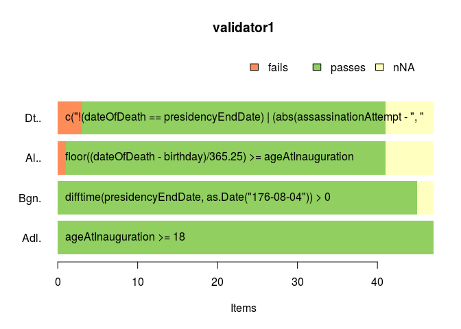

```r
barplot(confront_messy)
```

What errors were there:

```r
errors(confront_messy)
```

```
## $Positive.first.name
## [1] "non-numeric argument to binary operator"
```

What warnings were there:

```r
warnings(confront_messy)
```

```
## named list()
```

# Make Codebook

Show

```r
makeCodebook(bpd_clean)
```

# Pros and Cons

Show

# Resources

Ekstrom, C.T., Peterson, A.H. (2018, February). Cleaning Up the Data Cleaning Process. Short course at the Conference on Statistical Practice, Portland, OR.

Ekstrom, C.T., Peterson, A.H. (2018, February). Cleaning Up the Data Cleaning Process. Short course at the Conference on Statistical Practice, Portland, OR [*Course slides*] .